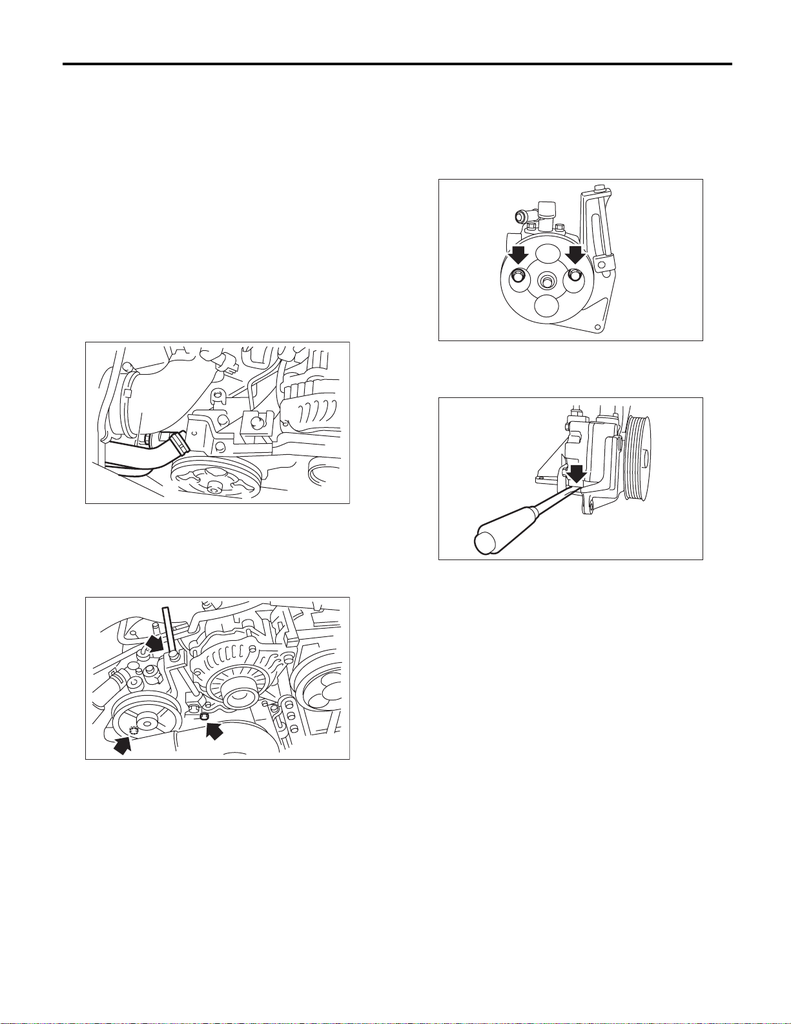

PS-77

Oil Pump

POWER ASSISTED SYSTEM (POWER STEERING)

9. Oil Pump

A: REMOVAL

1) Disconnect the ground cable from battery.

2) Remove the V-belts (front side belt). <Ref. to

ME(STI)-41, REMOVAL, V-belt.>

3) Disconnect the connector from power steering

pump switch.

4) Disconnect the pressure hose and suction hose

from the oil pump.

CAUTION:

• Do not allow fluid to come into contact with

the pulley belt.

• To prevent foreign matter from entering the

hose and pipe, cover the open ends with clean

cloth.

5) Remove the installation bolt of the power steer-

ing pump bracket.

6) Place the oil pump bracket in a vise, and remove

the two bolts from the front side of the oil pump.

CAUTION:

When securing the oil pump bracket in a vice,

hold the oil pump bracket with the least possi-

ble force between two pieces of wood.

7) Remove the bolt from the rear side of oil pump.

8) Disassemble the oil pump and bracket by insert-

ing a flat tip screwdriver as shown in the figure.

(1) Suction hose

(2) Pressure hose

PS-00459

(2)

(1)

PS-00188

PS-00128

PS-00129

15WRX_STI_US_EN.book 77 ページ ２０１５年２月１３日 金曜日 午前１１時２０分

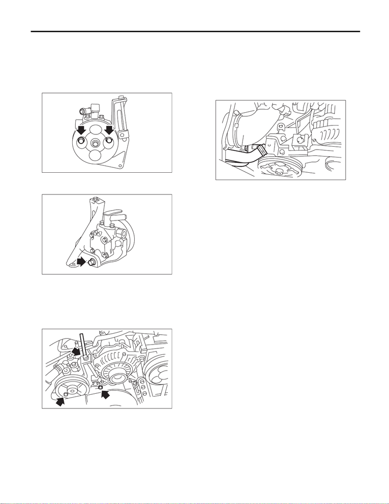

PS-78

Oil Pump

POWER ASSISTED SYSTEM (POWER STEERING)

B: INSTALLATION

1) Install the oil pump to bracket.

2) Tighten the bolts which hold the oil pump to the

bracket.

Tightening torque:

16 N·m (1.6 kgf-m, 11.8 ft-lb)

Tightening torque:

48 N·m (4.9 kgf-m, 35.4 ft-lb)

3) Attach the installation bolts of the power steering

pump bracket.

Tightening torque:

Refer to “COMPONENT” of “General Descrip-

tion”. <Ref. to PS-8, OIL PUMP, COMPO-

NENT, General Description.>

4) Connect the pressure hose and suction hose.

CAUTION:

Be careful when installing; If the hose is twisted

it may come into contact with other parts.

Tightening torque:

Eyebolt

40 N·m (4.1 kgf-m, 29.5 ft-lb)

5) Connect the power steering pump switch to the

connector.

6) After installing the oil pump, fill the oil pump with

fluid while rotating the pulley by hand and bleed the

air from the oil pump.

CAUTION:

Always fill the oil pump with the fluid to prevent

abnormal noise and seizure of the oil pump.

7) Install the V-belts (front side belt). <Ref. to

ME(STI)-41, INSTALLATION, V-belt.>

8) Connect the battery ground terminal.

9) Fill with the specified power steering fluid. <Ref.

to PS-83, Power Steering Fluid.>

CAUTION:

Never start the engine before filling with fluid;

otherwise the vane pump may become seized.

PS-00128

PS-00137

PS-00188

(1) Suction hose

(2) Pressure hose

PS-00459

(2)

(1)

15WRX_STI_US_EN.book 78 ページ ２０１５年２月１３日 金曜日 午前１１時２０分

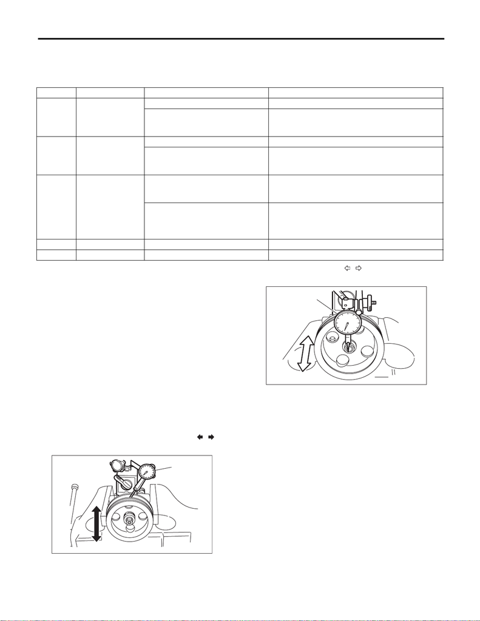

PS-79

Oil Pump

POWER ASSISTED SYSTEM (POWER STEERING)

C: INSPECTION

1. BASIC INSPECTION

Perform the following inspection procedures and replace faulty parts.

2. SERVICE LIMIT

Make a measurements as follows. If it exceeds the

service limit, replace with a new part.

CAUTION:

• When securing the oil pump in a vice, hold

the oil pump with the least possible force be-

tween two pieces of wood.

• Do not set the outside of flow control valve or

pulley on a vise; otherwise outside or pulley

might be deformed. Select properly sized wood

pieces.

1) Play of the pulley shaft

Condition:

P: When applying a force of 9.8 N (1.0 kgf, 2.2

lbf)

Service limit:

Play in the radial direction (direction )

0.2 mm (0.008 in) or less

Axial play (direction )

0.9 mm (0.035 in) or less

No. Parts Inspection Corrective action

1 Oil pump (exterior)

(1) Crack, damage or oil leakage Replace the oil pump with a new part.

(2) Play of pulley shaft

Measure the radial play and axial play.

If any of these exceeds the service limit, replace the

oil pump with a new part.

2Pulley

(1) Damage Replace the oil pump with a new part.

(2) Bend

Measure the V groove deflection.

If it exceeds the service limit, replace the oil pump with

a new part.

3 Oil pump (interior)

(1) Faulty or seized of vane pump

Check the rotating resistance of pulley.

If it exceeds the service limit, replace the oil pump with

a new part.

(2) Bend in the shaft or damage to

bearing

If the a string is wrapped on the pulley and rotated,

and the oil pump emits a noise that is markedly differ-

ent in tone and loudness from a sound of a new oil

pump, replace the oil pump with a new part.

4 O-ring Cracking or deterioration Replace with a new part.

5 Bracket Cracks Replace with a new part.

(1) Dial gauge

P

(1)

PS-00145

(1) Dial gauge

P

(1)

PS-00146

15WRX_STI_US_EN.book 79 ページ ２０１５年２月１３日 金曜日 午前１１時２０分

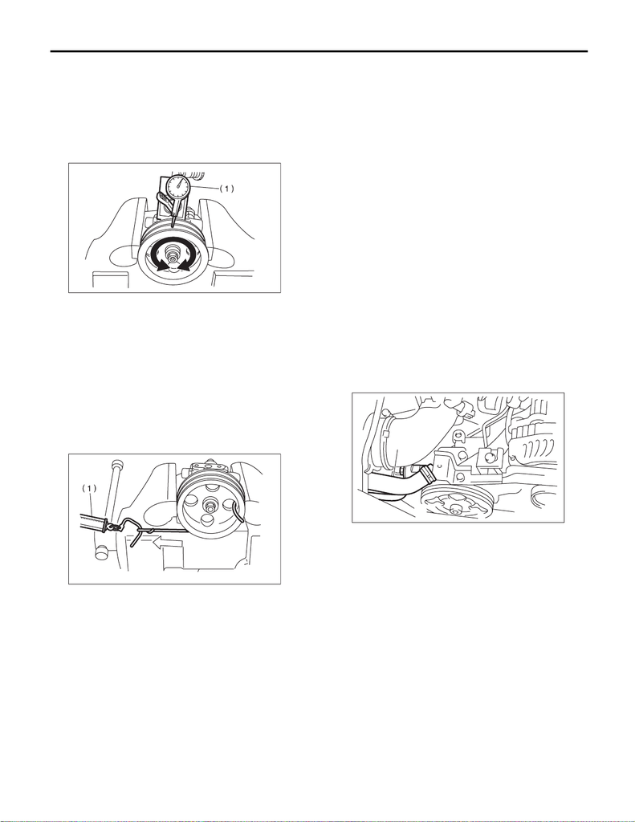

PS-80

Oil Pump

POWER ASSISTED SYSTEM (POWER STEERING)

2) Deflection of the pulley groove

Service limit:

1.0 mm (0.039 in) or less

NOTE:

Read the value on one surface of V groove, set the

dial gauge on the other surface, and read the value

of the dial gauge.

3) Rotating resistance of pulley

Service limit:

Maximum load: 9.22 N (0.94 kgf, 2.07 lbf) or

less

NOTE:

• A rather higher value may be indicated when pul-

ley starts turning.

• Measure the load during rotation to make a judg-

ment.

3. HYDRAULIC PRESSURE

NOTE:

• To measure hydraulic pressure correctly, be

sure to complete all the items in “INSPECTION”,

prior to performing the measurement. <Ref. to PS-

87, INSPECTION, General Diagnostic Table.>

• Do not leave the valve of pressure gauge closed

or hold the steering wheel at lock for 5 seconds or

more in any case, this can damage the oil pump.

• Before attaching a pressure gauge, place cloth

at locations where fluid is expected to spill. Wipe off

any spilt fluid completely after the measurement.

1) Regular pressure measurement

(1) Connect the ST.

Preparation tool:

ST1: PRESSURE GAUGE (925711000)

ST2: ADAPTER HOSE B (34099AC020)

ST3: ADAPTER HOSE A (34099AC010)

(2) Remove the air intake duct. <Ref. to

IN(STI)-11, REMOVAL, Air Intake Duct.>

(3) Disconnect the pressure hose from the

pump.

(4) Using the gasket (Part No. 34621AC021)

and bolt (Part No. 34620AC010), install the ST2

to pump instead of pressure hose.

(1) Dial gauge

(1) Spring scale

PS-00147

PS-00148

(1) Suction hose

(2) Pressure hose

PS-00459

(2)

(1)

15WRX_STI_US_EN.book 80 ページ ２０１５年２月１３日 金曜日 午前１１時２０分

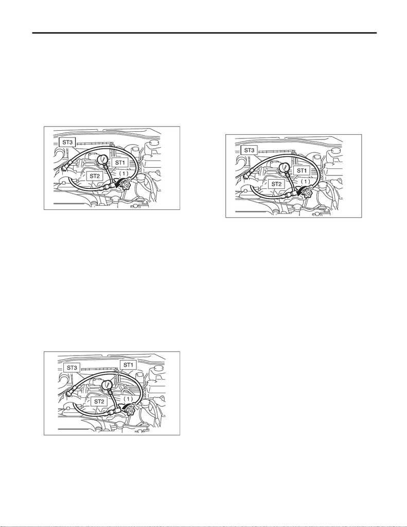

PS-81

Oil Pump

POWER ASSISTED SYSTEM (POWER STEERING)

(5) Attach the ST3 to the end of pressure hose

which is removed from pump.

(6) Replenish power steering fluid up to the

specified level.

(7) Open the valve, and start the engine.

(8) Measure the regular pressure.

Preparation tool:

ST1: PRESSURE GAUGE (925711000)

ST2: ADAPTER HOSE B (34099AC020)

ST3: ADAPTER HOSE A (34099AC010)

Service limit:

981 kPa (10 kgf/cm

2

, 142 psi) or less

(9) If it is not within the specification, replace the

faulty part for the following problems. (Pipe or

hose clogged, leaks from fluid line, and mixture

of foreign matter in fluid line)

2) Measure the relief pressure.

(1) Using the ST, measure the relief pressure.

(2) Close the valve.

(3) Measure the relief pressure.

Preparation tool:

ST1: PRESSURE GAUGE (925711000)

ST2: ADAPTER HOSE B (34099AC020)

ST3: ADAPTER HOSE A (34099AC010)

Service limit:

8,300 — 9,000 kPa (85 — 92 kgf/cm

2

, 1,203 —

1,305 psi)

(4) If the torque is not within specified range, re-

place the oil pump.

3) Measure the operating pressure.

(1) Using the ST, measure the operating pres-

sure.

(2) Open the valve.

(3) Measure the operating pressure of control

valve by turning steering wheel from stop to

stop.

Preparation tool:

ST1: PRESSURE GAUGE (925711000)

ST2: ADAPTER HOSE B (34099AC020)

ST3: ADAPTER HOSE A (34099AC010)

Service limit:

8,300 — 9,000 kPa (85 — 92 kgf/cm

2

, 1,203 —

1,305 psi)

(4) If it is out of specification, measure the

steering effort. <Ref. to PS-91, MEASURE-

MENT OF STEERING EFFORT (HYDRAULIC

TYPE), INSPECTION, General Diagnostic Ta-

ble.>

If it is not within specification, replace the con-

trol valve itself or control valve and pinion as a

single unit, using new parts.

(1) Valve

(1) Valve

PS-00152

PS-00153

(1) Valve

PS-00152

15WRX_STI_US_EN.book 81 ページ ２０１５年２月１３日 金曜日 午前１１時２０分